# Download data from WID.world into R

## Plot top wealth shares in France since the 1800s

In this example, we still select only one indicator, but we ask for two different percentiles. The function still returns a `data.frame` in “long” format, which makes it easy to plot with `ggplot2`.

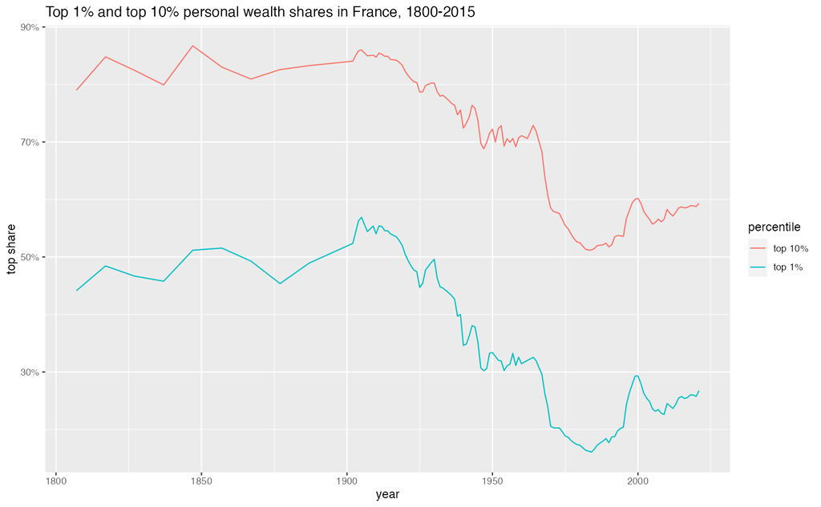

```r
data <- download_wid(
    indicators = "shweal", # Shares of personal wealth
    areas = "FR", # In France
    perc = c("p90p100", "p99p100") # Top 1% and top 10%
)
library(ggplot2)
library(scales)
ggplot(data) +
    geom_line(aes(x = year, y = value, color = percentile)) +
    ylab("top share") +
    scale_y_continuous(label = percent) +
    scale_color_discrete(labels = c("p90p100" = "top 10%", "p99p100" = "top 1%")) +
    ggtitle("Top 1% and top 10% personal wealth shares in France, 1800-2015")
```

## Evolution of income for the bottom 50% of the population

We now focus solely on the bottom half of the population (`p0p50`), and look at the average pre-tax national income in three different countries (France, United States and China). Since we are looking at monetary amounts for three different countries, we need to convert them into the same currency using the purchasing power parities in the database.

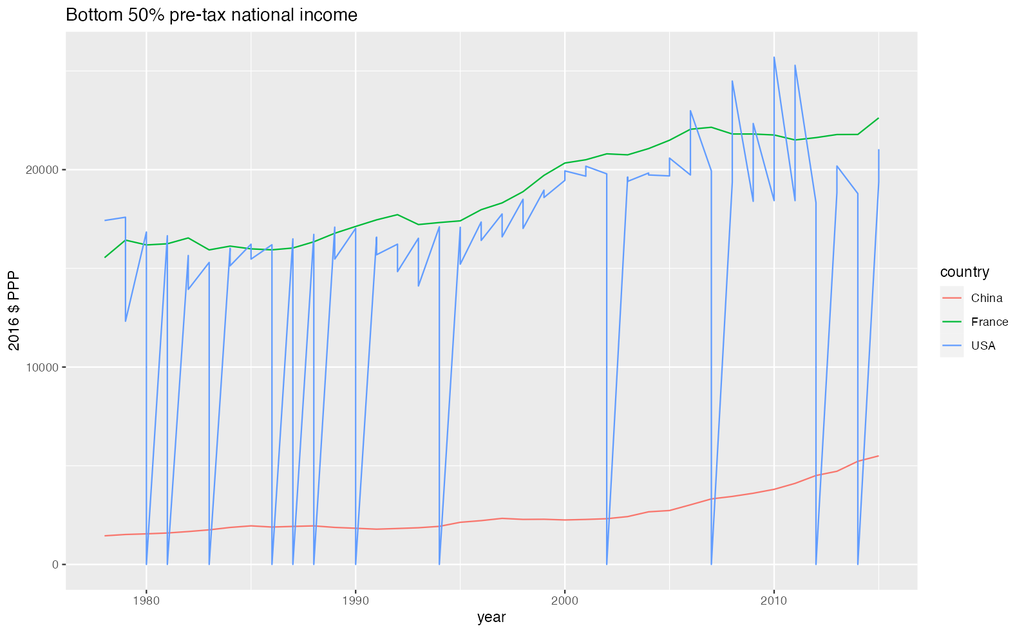

```r
# We use the tidyverse to manipulate the data, see http://tidyverse.org
library(tidyverse)
# Average incomes data
data <- download_wid(
    indicators = "aptinc", # Average pre-tax national income
    areas = c("FR", "CN", "US"), # France, China and United States
    perc = "p0p50", # Bottom half of the population
    pop = "j", # Equal-split individuals
    year = 1978:2015
) %>% rename(value_lcu = value)
# Purchasing power parities with US dollar
ppp <- download_wid(
    indicators = "xlcusp", # US PPP
    areas = c("FR", "CN", "US"), # France, China and United States
    year = 2016 # Reference year only
) %>% rename(ppp = value) %>% select(-year, -percentile)
# Convert from local currency to PPP US dollar
data <- merge(data, ppp, by = "country") %>%
    mutate(value_ppp = value_lcu/ppp)
ggplot(data) +
    geom_line(aes(x = year, y = value_ppp, color = country)) +
    ylab("2016 $ PPP") +
    scale_color_discrete(labels = c("CN" = "China", "US" = "USA", "FR" = "France")) +
    ggtitle("Bottom 50% pre-tax national income")
```

## Evolution of national income over long period

We now plot the evolution of average net national income per adult in France, Germany, the United Kingdom and the United States.

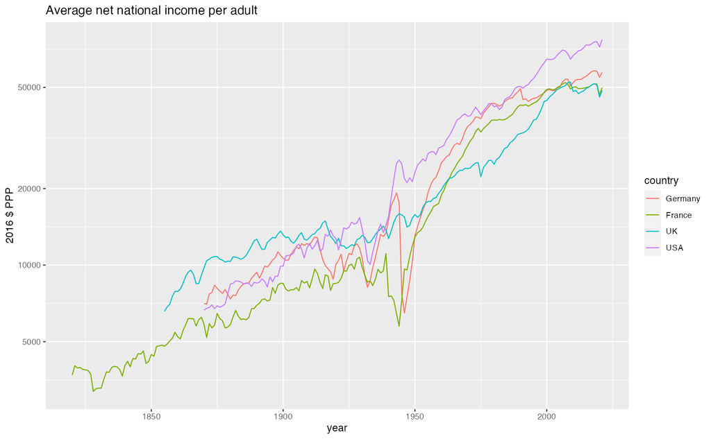

```r
# Average national income data
data <- download_wid(
    indicators = "anninc", # Average net national income
    areas = c("FR", "US", "DE", "GB"),
    ages = 992 # Adults
) %>% rename(value_lcu = value)
# Purchasing power parities with US dollar
ppp <- download_wid(
    indicators = "xlcusp", # US PPP
    areas = c("FR", "US", "DE", "GB"), # France, China and United States
    year = 2016 # Reference year only
) %>% rename(ppp = value) %>% select(-year, -percentile)
# Convert from local currency to PPP US dollar
data <- merge(data, ppp, by = "country") %>%
    mutate(value_ppp = value_lcu/ppp)
ggplot(data) +
    geom_line(aes(x = year, y = value_ppp, color = country)) +
    scale_y_log10(breaks = c(2e3, 5e3, 1e4, 2e4, 5e4)) +
    ylab("2016 $ PPP") +
    scale_color_discrete(
        labels = c("US" = "USA", "FR" = "France", "DE" = "Germany", "GB" = "UK")
    ) +
    ggtitle("Average net national income per adult")
```

## Divergence of incomes in the United States since 1970

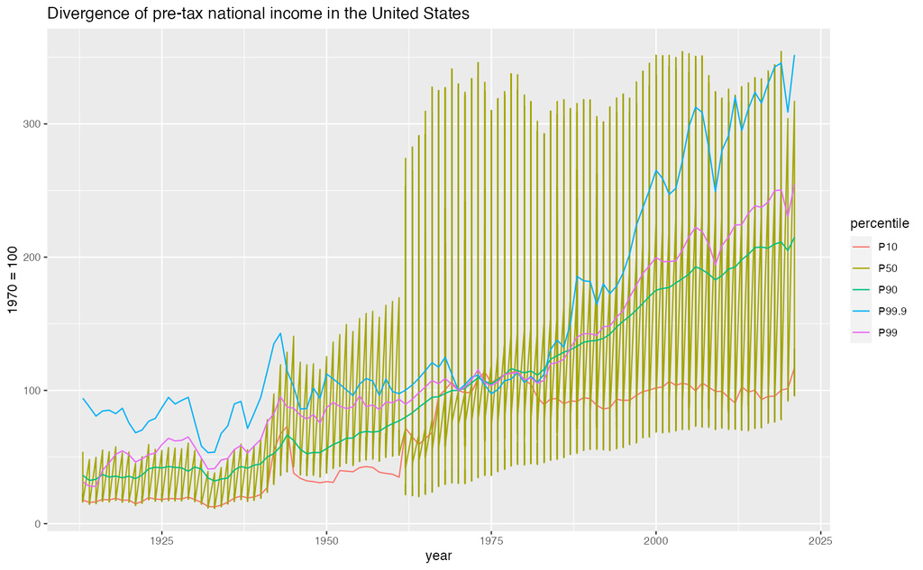

```r
data <- download_wid(
    indicators = "tptinc", # Thresholds of pre-tax national income
    areas = "US", # United States
    perc = c("p10p100", "p50p100", "p90p100", "p99p100", "p99.9p100")
)
# Keep the value for 1970 in a separate data.frame
data1970 <- data %>% filter(year == 1970) %>%
    rename(value1970 = value) %>%
    select(-year)
# Divide series by the reference year (1970)
data <- merge(data, data1970, by = c("country", "percentile")) %>%
    mutate(value = 100*value/value1970)
ggplot(data) +
    geom_line(aes(x = year, y = value, color = percentile)) +
    ylab("1970 = 100") +
    scale_color_discrete(
        labels = c("p10p100" = "P10", "p50p100" = "P50", "p90p100" = "P90",
            "p99p100" = "P99", "p99.9p100" = "P99.9")
    ) +
    ggtitle("Divergence of pre-tax national income in the United States")
```

## Including or excluding extrapolations

In some countries, many data points are the result of interpolations or extrapolations. For example, estimates in most African countries are based on surveys that are only realized every few years, which we interpolate to produce yearly series and perform regional aggregations. For example, takethe inequality series for Mozambique:

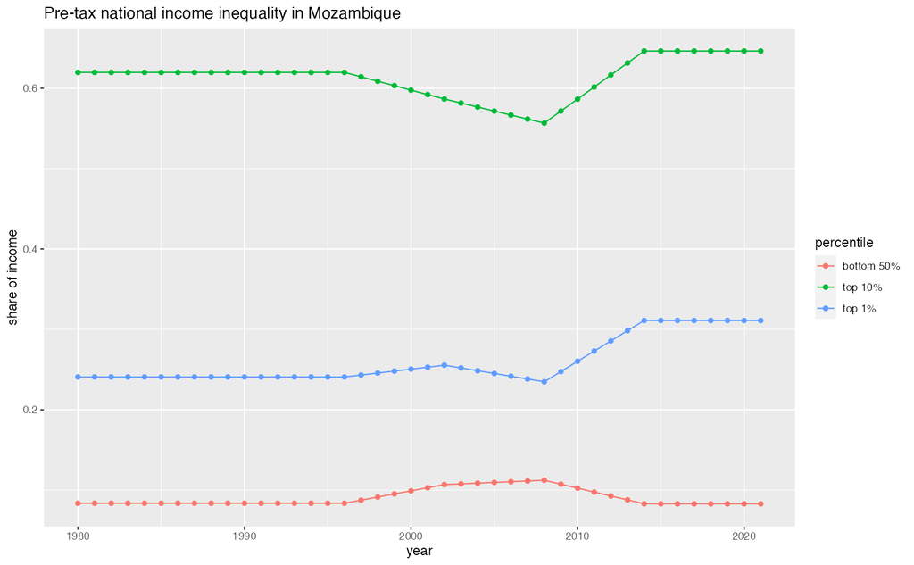

```r
data <- download_wid(
    indicators = "sptinc", # Shares of pre-tax national income
    areas = "MZ", # Mozambique
    perc = c("p0p50", "p90p100", "p99p100") # Bottom 50%, top 10% and top 1%
)
ggplot(data, aes(x = year, y = value, color = percentile)) +
    geom_line() + geom_point() +
    ylab("share of income") +
    scale_color_discrete(
        labels = c("p0p50" = "bottom 50%", "p90p100" = "top 10%", "p99p100" = "top 1%")
    ) +
    ggtitle("Pre-tax national income inequality in Mozambique")
```

The linear interpolation is quite visible. In some contexts, this might be undesirable. To exclude interpolated points, use `include_extrapolations = FALSE`:

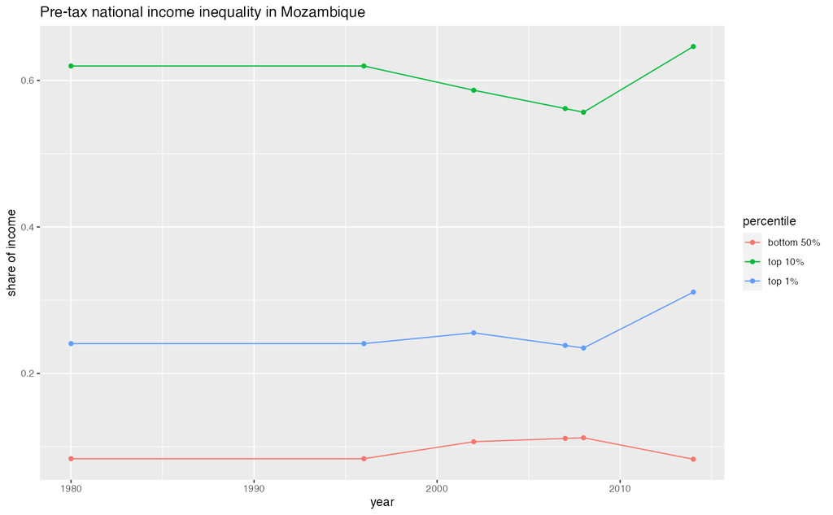

```r
data <- download_wid(
    indicators = "sptinc", # Shares of pre-tax national income
    areas = "MZ", # Mozambique
    perc = c("p0p50", "p90p100", "p99p100"), # Bottom 50%, top 10% and top 1%
    include_extrapolations = FALSE # Do not include interpolations
)
ggplot(data, aes(x = year, y = value, color = percentile)) +
    geom_line() + geom_point() +
    ylab("share of income") +
    scale_color_discrete(
        labels = c("p0p50" = "bottom 50%", "p90p100" = "top 10%", "p99p100" = "top 1%")
    ) +
    ggtitle("Pre-tax national income inequality in Mozambique")
```